# PREDICTION OF NEXT WEEK'S COVID 19 DEATHS BASED ON THIS WEEK'S DATA

##### SACKO Kalil, Master Student at University of applied Science Bochum, major : Computer Science

# Introduction

This project focuses on predicting COVID-19-related deaths for the upcoming week based on data from the current week. It is a seminar project in the field of Big Data, inspired by a Kaggle competition. The competition that serves as the foundation for this project can be found at the following link: https://www.kaggle.com/competitions/Covid19-Death-Predictions/overview.

The goal of the project is to make accurate predictions while gaining significant insights from the data. Modern analytical methods and machine learning techniques are employed to address the challenges posed by this real-world scenario.

# -------------------------------APPROACH-----------------------------

# I. EXPLORATORY DATA ANALYSIS

# Objective:

**To understand the available data as thoroughly as possible in order to define a modeling strategy.**

# Basic Checklist (not exhaustive):

# I-I. Basic Analysis (Analysis of the Data Structure)

- **Target Variable**
- **Number of Rows and Columns**
- **Variable Types**
- **Descriptive Analysis**
- **Analysis of Missing Values**
- **Analysis of Outliers**
- **Analysis of Variable Distributions**

## I-II. Content Analysis:

- **Objective**:

**To examine the relationships between variables and identify potential hypotheses for testing**

- **Exploration of the Target Variable**
- **Relationships between Variables and the Target Variable**
- **Relationships among Independent Variables**
- **Temporal and Geographical Analysis**
- **Vaccination and Its Effects**

## I-III. Hypotheses to be tested:

### Null Hypotheses (H₀)

- **Hypothesis 1: Do regions with higher vaccination rates have lower weekly death counts?**
- **Hypothesis 2: Do regions with higher COVID-19 case numbers have higher death rates?**
- **Hypothese 3 : Hypothesis 3: Do regions with higher weekly death rates also have higher death rates in the following week**
- **ETC....**

# Objective:

**To transform the data into a format suitable for machine learning.**

## Basic Checklist (not exhaustive):

- **Creation of Training and Validation(pre-test) Datasets**
- **Encoding**
- **Handling NaN Values: dropna(), Imputation**
- **Treatment of Outliers that Negatively Affect the Model**
- **Feature Selection**
- **Feature Engineering**
- **Feature Scaling**

# III. MODELLING AND TRAINING

# Objective:

**To Develop a machine learning model that fulfills the ultimate goal.**

## Basic Checklist (not exhaustive):

- **Definition of an Evaluation Function**
- **Training Various Models**
- **Learning Curve**
- **Coefficient of Determination (R² Score)**
- **Error Analysis and Returning to Preprocessing/EDA (Optional)**
- **Optimization: Using GridSearchCV and/or RandomizedSearchCV , Applying Ensemble Learners**

# IV. TEST PHASE

- **Final test of the selected best model(s) with a new dataset (test set).**

```python
import pandas as pd
import seaborn as sns
import matplotlib.pyplot as plt
```

```python
pd.set_option('display.max_rows', 111)
pd.set_option('display.max_columns', 111)
```

```python
data = pd.read_csv('train.csv')
```

# I. EXPLORATORY DATA ANALYSIS

## I-I. Basic Analysis (Analysis of the Data Structure)

#### Number of rows and columns

```python
data
```

|  | Id | Location | Weekly Cases | Year | Weekly Cases per Million | Weekly Deaths | Weekly Deaths per Million | Total Vaccinations | People Vaccinated | People Fully Vaccinated | Total Boosters | Daily Vaccinations | Total Vaccinations per Hundred | People Vaccinated per Hundred | People Fully Vaccinated per Hundred | Total Boosters per Hundred | Daily Vaccinations per Hundred | Daily People Vaccinated | Daily People Vaccinated per Hundred | Next Week's Deaths |
| --- | --- | --- | --- | --- | --- | --- | --- | --- | --- | --- | --- | --- | --- | --- | --- | --- | --- | --- | --- | --- |
| 0 | 911530868 | World | 2372.0 | 2020 | 0.300 | 65.0 | 0.008 | NaN | NaN | NaN | NaN | NaN | NaN | NaN | NaN | NaN | NaN | NaN | NaN | 344.0 |
| 1 | 807936902 | World | 5023.0 | 2020 | 0.635 | 114.0 | 0.014 | NaN | NaN | NaN | NaN | NaN | NaN | NaN | NaN | NaN | NaN | NaN | NaN | 361.0 |
| 2 | 773590408 | World | 5612.0 | 2020 | 0.710 | 116.0 | 0.015 | NaN | NaN | NaN | NaN | NaN | NaN | NaN | NaN | NaN | NaN | NaN | NaN | 431.0 |
| 3 | 130466459 | World | 7580.0 | 2020 | 0.958 | 153.0 | 0.019 | NaN | NaN | NaN | NaN | NaN | NaN | NaN | NaN | NaN | NaN | NaN | NaN | 463.0 |
| 4 | 544040446 | World | 8983.0 | 2020 | 1.136 | 187.0 | 0.024 | NaN | NaN | NaN | NaN | NaN | NaN | NaN | NaN | NaN | NaN | NaN | NaN | 506.0 |
| ... | ... | ... | ... | ... | ... | ... | ... | ... | ... | ... | ... | ... | ... | ... | ... | ... | ... | ... | ... | ... |
| 129151 | 541829605 | Zimbabwe | 464.0 | 2022 | 29.012 | 13.0 | 0.813 | 11949993.0 | 6297324.0 | 4601845.0 | 1050824.0 | 5665.0 | 74.72 | 39.37 | 28.77 | 6.57 | 354.0 | 1427.0 | 0.009 | 9.0 |
| 129152 | 969939474 | Zimbabwe | 471.0 | 2022 | 29.449 | 12.0 | 0.750 | 11958771.0 | 6299348.0 | 4605821.0 | 1053602.0 | 5295.0 | 74.77 | 39.39 | 28.80 | 6.59 | 331.0 | 1362.0 | 0.009 | 7.0 |
| 129153 | 667902340 | Zimbabwe | 450.0 | 2022 | 28.136 | 13.0 | 0.813 | NaN | NaN | NaN | NaN | 5316.0 | NaN | NaN | NaN | NaN | 332.0 | 1483.0 | 0.009 | 5.0 |
| 129154 | 961193720 | Zimbabwe | 277.0 | 2022 | 17.320 | 6.0 | 0.375 | 11974313.0 | 6305470.0 | 4611113.0 | 1057730.0 | 5358.0 | 74.87 | 39.43 | 28.83 | 6.61 | 335.0 | 1633.0 | 0.010 | 7.0 |
| 129155 | 832612563 | Zimbabwe | 277.0 | 2022 | 17.320 | 6.0 | 0.375 | 11984914.0 | 6310089.0 | 4614738.0 | 1060087.0 | 6190.0 | 74.94 | 39.45 | 28.85 | 6.63 | 387.0 | 2102.0 | 0.013 | 8.0 |

129156 rows × 20 columns

```python
print("Number of rows in the dataset : ", len(data))
print("Number of columns in the dataset : ", len(data.columns))
print("THE TARGET VARIABLE IS 'Next Week's Deaths' : ")
```

```
Number of rows in the dataset :  129156
Number of columns in the dataset :  20
THE TARGET VARIABLE IS 'Next Week's Deaths' :
```

#### Variable Types

```python
#Variable types
data.dtypes
```

```
Id                                       int64
Location                                object
Weekly Cases                           float64
Year                                     int64
Weekly Cases per Million               float64
Weekly Deaths                          float64
Weekly Deaths per Million              float64
Total Vaccinations                     float64
People Vaccinated                      float64
People Fully Vaccinated                float64
Total Boosters                         float64
Daily Vaccinations                     float64
Total Vaccinations per Hundred         float64
People Vaccinated per Hundred          float64
People Fully Vaccinated per Hundred    float64
Total Boosters per Hundred             float64
Daily Vaccinations per Hundred         float64
Daily People Vaccinated                float64
Daily People Vaccinated per Hundred    float64
Next Week's Deaths                     float64
dtype: object
```

```
float64    17
int64       2
object      1
Name: count, dtype: int64
```

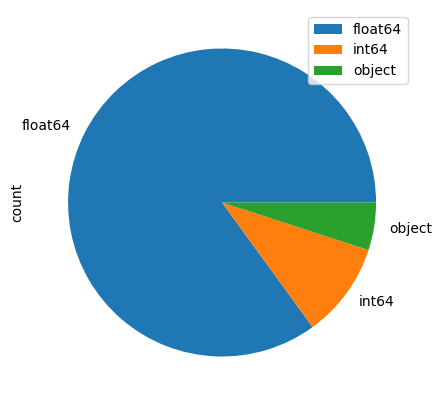

```python
print(data.dtypes.value_counts())
data.dtypes.value_counts().plot(kind='pie', legend=True, figsize=(8,5))
```

#### Descriptive Analysis

```python
#Descriptive Analysis
data.describe()
```

|  | Id | Weekly Cases | Year | Weekly Cases per Million | Weekly Deaths | Weekly Deaths per Million | Total Vaccinations | People Vaccinated | People Fully Vaccinated | Total Boosters | Daily Vaccinations | Total Vaccinations per Hundred | People Vaccinated per Hundred | People Fully Vaccinated per Hundred | Total Boosters per Hundred | Daily Vaccinations per Hundred | Daily People Vaccinated | Daily People Vaccinated per Hundred | Next Week's Deaths |
| --- | --- | --- | --- | --- | --- | --- | --- | --- | --- | --- | --- | --- | --- | --- | --- | --- | --- | --- | --- |
| count | 1.291560e+05 | 1.289430e+05 | 129156.000000 | 128288.000000 | 127898.000000 | 127247.000000 | 4.027000e+04 | 3.842900e+04 | 3.657400e+04 | 1.984700e+04 | 7.784000e+04 | 40270.000000 | 38429.000000 | 36574.000000 | 19847.000000 | 77840.000000 | 7.739100e+04 | 77391.000000 | 129156.000000 |
| mean | 5.502597e+08 | 9.520131e+04 | 2020.912919 | 1379.071563 | 1072.815494 | 10.845384 | 2.450093e+08 | 1.174096e+08 | 9.862264e+07 | 4.365458e+07 | 4.742138e+05 | 89.723652 | 43.424276 | 38.421866 | 20.160324 | 2702.988798 | 1.823430e+05 | 0.114669 | 1064.082776 |
| std | 2.599890e+08 | 6.329716e+05 | 0.739667 | 4013.421702 | 5287.848128 | 24.740908 | 1.032824e+09 | 4.932070e+08 | 4.303844e+08 | 1.862997e+08 | 2.593336e+06 | 74.209648 | 30.074617 | 29.197973 | 22.598973 | 3468.942102 | 1.061855e+06 | 0.202150 | 5251.447471 |
| min | 1.000006e+08 | 0.000000e+00 | 2020.000000 | 0.000000 | 0.000000 | 0.000000 | 0.000000e+00 | 0.000000e+00 | 1.000000e+00 | 1.000000e+00 | 0.000000e+00 | 0.000000 | 0.000000 | 0.000000 | 0.000000 | 0.000000 | 0.000000e+00 | 0.000000 | 0.000000 |
| 25% | 3.253421e+08 | 1.040000e+02 | 2020.000000 | 18.291500 | 1.000000 | 0.050000 | 9.900038e+05 | 5.771390e+05 | 4.683338e+05 | 3.894150e+04 | 1.065000e+03 | 18.730000 | 12.810000 | 8.390000 | 0.295000 | 402.000000 | 3.280000e+02 | 0.012000 | 1.000000 |
| 50% | 5.497285e+08 | 1.084000e+03 | 2021.000000 | 188.584000 | 13.000000 | 1.709000 | 7.772026e+06 | 4.306986e+06 | 3.811594e+06 | 1.397130e+06 | 9.182500e+03 | 79.195000 | 46.330000 | 38.515000 | 9.780000 | 1498.000000 | 3.287000e+03 | 0.046000 | 13.000000 |
| 75% | 7.756598e+08 | 9.750000e+03 | 2021.000000 | 1046.367750 | 127.000000 | 10.934000 | 4.976308e+07 | 2.557442e+07 | 2.168825e+07 | 1.114840e+07 | 6.394475e+04 | 146.290000 | 70.380000 | 64.720000 | 36.860000 | 3840.000000 | 2.318000e+04 | 0.141000 | 125.000000 |
| max | 9.999993e+08 | 2.406618e+07 | 2022.000000 | 104220.239000 | 103568.000000 | 1040.710000 | 1.212140e+10 | 5.255161e+09 | 4.816606e+09 | 2.129044e+09 | 4.368841e+07 | 366.870000 | 128.780000 | 126.790000 | 125.850000 | 117862.000000 | 2.099974e+07 | 11.786000 | 102123.000000 |

#### Skewness:

- Most columns show a strong **skewness**, which is typical for data with minimal values close to zero and very high maximum values (long-tailed distribution). For example:

**Weekly Cases, Weekly Deaths, Total Vaccinations, People Vaccinated**, etc., exhibit a large difference between the **median (50%)** and the **mean**. This suggests a **right-skewed distribution**. The presence of very high maximum values (e.g., **Weekly Cases = 24,066,180 and Weekly Deaths = 103,568**) reinforces the idea that these distributions are not **symmetrical**.

#### Distributions around the Median:

- No column seems to be well-distributed around the **median** due to the strong skewness. For example, for **Weekly Deaths**, the **median is 13**, but the **mean is 1,072**, indicating the influence of some extremely high values.

The column **Total Vaccinations per Hundred** shows a **moderate** difference between the **median (79.195) and the mean (89.72)**, suggesting a somewhat **less skewed distribution**, but still **not perfectly symmetrical**.

#### Analysis of missing values

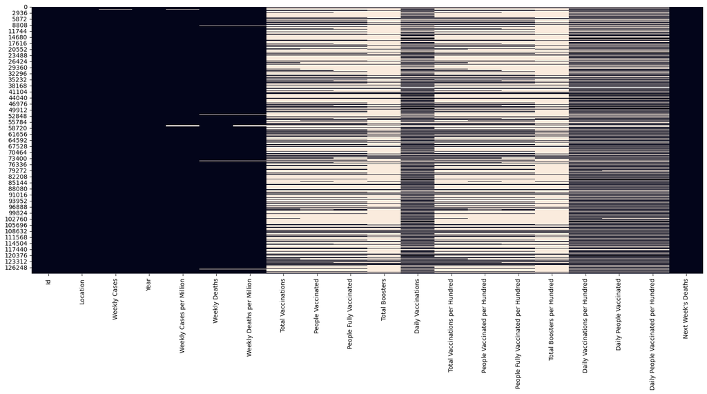

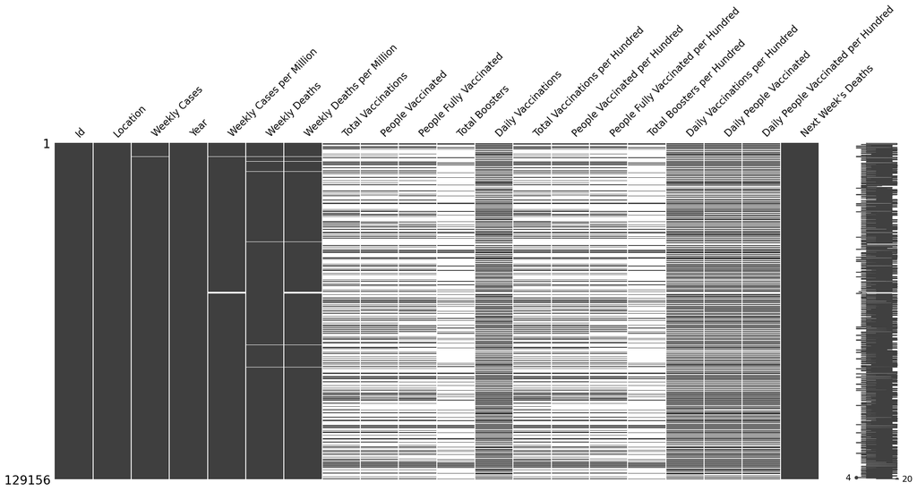

```python
#Analysis of missing values
import missingno as msno
plt.figure(figsize=(20, 8))
sns.heatmap(data.isna(), cbar=False)

msno.matrix(data)
```

```
Id                                      0.000000
Year                                    0.000000
Next Week's Deaths                      0.000000
Location                                0.000000
Weekly Cases                            0.164917
Weekly Cases per Million                0.672055
Weekly Deaths                           0.974016
Weekly Deaths per Million               1.478058
Daily Vaccinations per Hundred         39.731797
Daily Vaccinations                     39.731797
Daily People Vaccinated                40.079439
Daily People Vaccinated per Hundred    40.079439
Total Vaccinations per Hundred         68.820651
Total Vaccinations                     68.820651
People Vaccinated                      70.246059
People Vaccinated per Hundred          70.246059
People Fully Vaccinated per Hundred    71.682307
People Fully Vaccinated                71.682307
Total Boosters                         84.633312
Total Boosters per Hundred             84.633312
dtype: float64
```

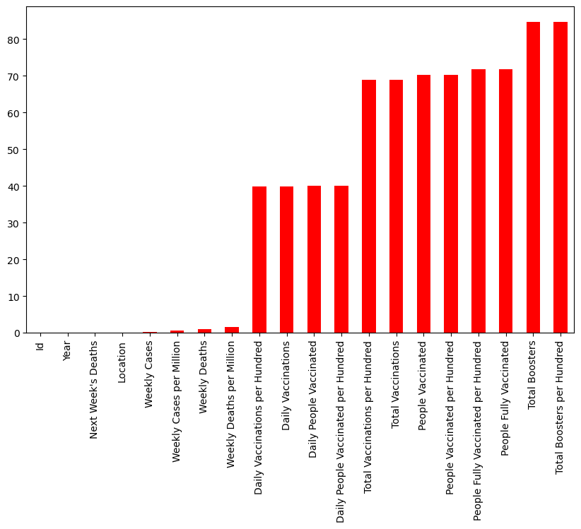

```python
# Percentage of missing values
missing_rate = (data.isna().sum()/data.shape[0])*100
print(missing_rate.sort_values())
missing_rate.sort_values().plot.bar(rot=90, figsize=(10,6), color = 'red')
```

```python
#The columns that contain more than 60% NaN values in the rows.
missing_groesser_60 = data.columns[missing_rate > 60]
print("More than 60% of the rows contain null values.\n\n",missing_groesser_60)

print("\n********************************************************************************")
missing_zwischen_39_40 = data.columns[(missing_rate > 38) & (missing_rate < 41)]
print("\nUp to 40% of the rows contain null values.\n\n", missing_zwischen_39_40)

print("\n********************************************************************************")
missing_sehr_klein = data.columns[missing_rate < 1.5]
print("\nContain almost no null values.\n\n", missing_sehr_klein)
```

```
More than 60% of the rows contain null values.

 Index(['Total Vaccinations', 'People Vaccinated', 'People Fully Vaccinated',
       'Total Boosters', 'Total Vaccinations per Hundred',
       'People Vaccinated per Hundred', 'People Fully Vaccinated per Hundred',
       'Total Boosters per Hundred'],
      dtype='object')


Up to 40% of the rows contain null values.

 Index(['Daily Vaccinations', 'Daily Vaccinations per Hundred',
       'Daily People Vaccinated', 'Daily People Vaccinated per Hundred'],
      dtype='object')


Contain almost no null values.

 Index(['Id', 'Location', 'Weekly Cases', 'Year', 'Weekly Cases per Million',
       'Weekly Deaths', 'Weekly Deaths per Million', 'Next Week's Deaths'],
      dtype='object')
```

#### ---------------------------------------------------------------------------------------------------------------------

- The columns **'Total Vaccinations', 'People Vaccinated', 'People Fully Vaccinated', 'Total Boosters', 'Total Vaccinations per Hundred', 'People Vaccinated per Hundred', 'People Fully Vaccinated per Hundred', and 'Total Boosters per Hundred'** have **NaN (null) values** in more than **60%** of the entire rows.
- The columns **'Daily Vaccinations', 'Daily Vaccinations per Hundred', 'Daily People Vaccinated', and 'Daily People Vaccinated per Hundred'** also contain **up to 40% null values**.
- The columns **'Id', 'Location', 'Weekly Cases', 'Year', 'Weekly Cases per Million', 'Weekly Deaths', 'Weekly Deaths per Million', and 'Next Week's Deaths'** have almost no (or very few – for the columns **Weekly Cases, Weekly Cases per Million, Weekly Deaths, Weekly Deaths per Million**) null values (**0-5%**).

#### Analysis of Outliers

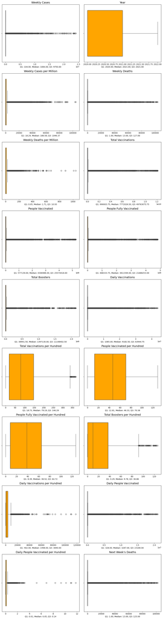

```python
# BOXPLOT OF COLUMNS
# for col in data.columns:
#     if data[col].dtype in ['int64', 'float64']:
#         Q1 = data[col].quantile(0.25)  # Erstes Quartil
#         Q3 = data[col].quantile(0.75)  # Drittes Quartil
#         median = data[col].median()

#         plt.figure(figsize=(8, 5))
#         sns.boxplot(data[col], boxprops=dict(facecolor='orange', edgecolor='black'))
#         plt.title(f'{col}', fontsize=14)

#         # Hinzufügen der statistischen Informationen als text.
#         plt.xlabel(f'Q1: {Q1:.2f}, Median: {median:.2f}, Q3: {Q3:.2f}', fontsize=12)
#         plt.ylabel('Werte', fontsize=12)

#         plt.show()

cols_per_row = 2
num_cols = len([col for col in data.drop(["Location", "Id"], axis=1).columns] )
rows = (num_cols + cols_per_row - 1) // cols_per_row  #Calculation of the required number of rows.

fig, axes = plt.subplots(rows, cols_per_row, figsize=(12, 5 * rows))
axes = axes.flatten()

for i, col in enumerate(data.drop(["Location", "Id"], axis=1).columns):
        Q1 = data[col].quantile(0.25)  # first Quartile
        Q3 = data[col].quantile(0.75)  # third Quartile
        median = data[col].median()  # Median

        sns.boxplot(ax=axes[i], x=data[col], boxprops=dict(facecolor='orange', edgecolor='black'))
        axes[i].set_title(f'{col}', fontsize=14)
        axes[i].set_xlabel(f'Q1: {Q1:.2f}, Median: {median:.2f}, Q3: {Q3:.2f}', fontsize=10)
        axes[i].set_ylabel('')

#Hiding unnecessary axes when the number of columns is odd.
for j in range(num_cols, len(axes)):
    axes[j].set_visible(False)


plt.tight_layout()
plt.show()
```

For certain variables such as **Weekly Cases, Weekly Deaths, Daily Vaccinations, Daily People Vaccinated, and Next Week's Deaths**, the following observations can be made:

- The values seem to be highly concentrated around a specific **value** or within a **certain range**, with a significant number of **outliers** above the **whiskers**. These outliers are represented by **circles**.
- The box is extremely small, indicating that the interquartile range (**IQR**) is very narrow. This suggests that most of the data lies within a tight range around the **median**.
- Since whiskers are defined as the **last values within 1.5xIQR above or below the quartiles (Q1 and Q3)**, for variables with a very small IQR and simultaneously a very large range of values (e.g., **Weekly Cases**), the whiskers are very close to the edges of the box or even merged with them, making them difficult to see.

#### Analysis of variables' distributions

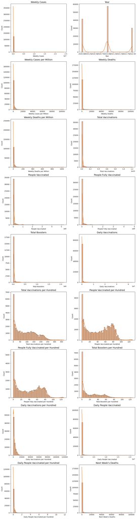

```python
# HISTOGRAMME OF THE VARIABLES

cols_per_row = 2
num_cols = len([col for col in data.drop(["Location", "Id"], axis=1).columns] )
rows = (num_cols + cols_per_row - 1) // cols_per_row  #Calculation of the number of required rows

fig, axes = plt.subplots(rows, cols_per_row, figsize=(12, 5 * rows))
axes = axes.flatten()

for i, col in enumerate(data.drop(["Location", "Id"], axis=1).columns) :
        sns.histplot(ax = axes[i], x = data[col], bins=50, kde=True,  color='chocolate')
        axes[i].set_title(f'{col}', fontsize=14)

#Hiding unnecessary axes when the number of columns is odd.
for j in range(num_cols, len(axes)):
    axes[j].set_visible(False)

plt.tight_layout()
plt.show()
```

```python
# SKEWNESS OF VARIABLES
skewdata = data.drop("Location", axis=1)
skewness = skewdata.skew()
print(f"Skewness of the features(columns) :\n{skewness}" )
```

```
Skewness of the features(columns) :
Id                                     -0.000918
Weekly Cases                           17.334228
Year                                    0.139635
Weekly Cases per Million                7.806967
Weekly Deaths                           9.096170
Weekly Deaths per Million               8.303667
Total Vaccinations                      7.061840
People Vaccinated                       6.846799
People Fully Vaccinated                 7.143399
Total Boosters                          6.990664
Daily Vaccinations                      9.282717
Total Vaccinations per Hundred          0.518582
People Vaccinated per Hundred          -0.023551
People Fully Vaccinated per Hundred     0.150049
Total Boosters per Hundred              0.934193
Daily Vaccinations per Hundred          5.123234
Daily People Vaccinated                10.693151
Daily People Vaccinated per Hundred    13.667387
Next Week's Deaths                      9.087042
dtype: float64
```

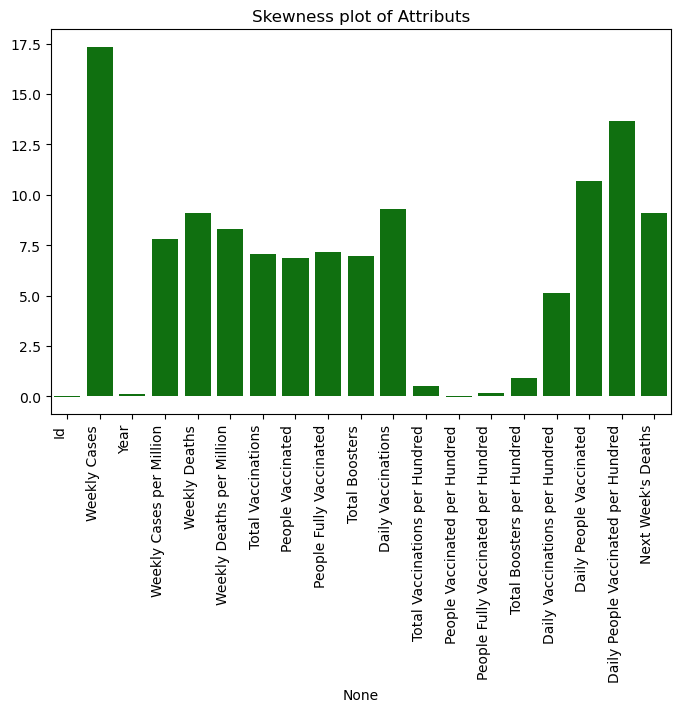

```python
plt.figure(figsize=(8,5))
sns.barplot(x = skewness.index, y = skewness.values, color='green')
plt.title("Skewness plot of Attributs")
plt.xticks(rotation=90, ha='right')
plt.show()
```

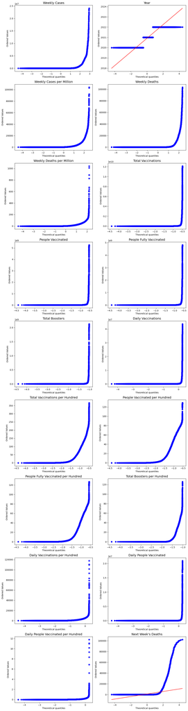

```python
# PROBABILITY PLOT
import scipy.stats as stats

cols_per_row = 2
num_cols = len([col for col in data.drop(["Location", "Id"], axis=1).columns] )
rows = (num_cols + cols_per_row - 1) // cols_per_row  #BCalculation of the number of required rows

fig, axes = plt.subplots(rows, cols_per_row, figsize=(12, 5 * rows))
axes = axes.flatten()

for i, col in enumerate(data.drop(["Location", "Id"], axis=1).columns) :

        stats.probplot(data[col], dist="norm", plot=axes[i])
        axes[i].set_title(f'{col}', fontsize=14)

#Hiding unnecessary axes when the number of columns is odd.
for j in range(num_cols, len(axes)):
    axes[j].set_visible(False)

plt.tight_layout()
plt.show()
```

### Interpretation of Skewness Values:

- A **skewness** close to **0** indicates a **symmetric distribution**.
- A positive **skewness (> 0)** suggests **right-skewness** (**long tail towards higher values**).
- A negative **skewness (< 0)** indicates **left-skewness** (**long tail towards lower values**).

### General Conclusions for the Variables:

#### Right-Skewed Variables (Skewness > 0):

Most columns exhibit a high **positive skewness**, suggesting **highly asymmetric distributions** with a **long tail towards higher values**.

### Highly Asymmetric Columns (Skewness > 7):

Columns such as:

**Weekly Cases (17.33) Weekly Deaths (9.09) Daily People Vaccinated (10.69) Daily People Vaccinated per Hundred (13.67) Daily Vaccinations (9.28) Weekly Cases per Million, Total Vaccinations, etc.**,have very high **skewness values (> 7)**. These values highlight the presence of some extremely high observations (outliers).

#### Moderately Right-Skewed Columns:

**Total Vaccinations per Hundred (0.51) Total Boosters per Hundred (0.93)** These columns show **moderate asymmetry**, indicating that their **distributions are less extreme** but still not **perfectly symmetric**.

#### Left-Skewed Variables (Skewness < 0):

**People Vaccinated per Hundred (-0.02)** The skewness is very close to **0**, suggesting an **almost symmetric distribution** for this column.

### ------------------------------------------------------------------------------------------------------------------------------

### Probability Plot

#### Axes of the Diagram:

- **X (Theoretical Quantiles)**: These represent the quantiles of a standard normal distribution (or another specified distribution).
- **Y (Ordered Values)**: These are the sorted data values from the sample.
- **Red Line (Reference Line)**: Represents an ideal normal distribution. If the blue points align with the red line, the data closely follows a normal distribution.

#### Deviations from the Line:

Points aligned on the red line: Indicate that the data fits a normal distribution well. Points deviating from the red line: Suggest that the data does not follow a normal distribution.

#### Findings Based on This Analysis:

It was observed that almost no variable in the dataset follows a normal distribution. Most distributions are asymmetric around their means, confirming deviations from normality.

## I-II. Content analysis:

#### Relationships between independent variables and the target variable

```python
data
```

|  | Id | Location | Weekly Cases | Year | Weekly Cases per Million | Weekly Deaths | Weekly Deaths per Million | Total Vaccinations | People Vaccinated | People Fully Vaccinated | Total Boosters | Daily Vaccinations | Total Vaccinations per Hundred | People Vaccinated per Hundred | People Fully Vaccinated per Hundred | Total Boosters per Hundred | Daily Vaccinations per Hundred | Daily People Vaccinated | Daily People Vaccinated per Hundred | Next Week's Deaths |
| --- | --- | --- | --- | --- | --- | --- | --- | --- | --- | --- | --- | --- | --- | --- | --- | --- | --- | --- | --- | --- |
| 0 | 911530868 | World | 2372.0 | 2020 | 0.300 | 65.0 | 0.008 | NaN | NaN | NaN | NaN | NaN | NaN | NaN | NaN | NaN | NaN | NaN | NaN | 344.0 |
| 1 | 807936902 | World | 5023.0 | 2020 | 0.635 | 114.0 | 0.014 | NaN | NaN | NaN | NaN | NaN | NaN | NaN | NaN | NaN | NaN | NaN | NaN | 361.0 |
| 2 | 773590408 | World | 5612.0 | 2020 | 0.710 | 116.0 | 0.015 | NaN | NaN | NaN | NaN | NaN | NaN | NaN | NaN | NaN | NaN | NaN | NaN | 431.0 |
| 3 | 130466459 | World | 7580.0 | 2020 | 0.958 | 153.0 | 0.019 | NaN | NaN | NaN | NaN | NaN | NaN | NaN | NaN | NaN | NaN | NaN | NaN | 463.0 |
| 4 | 544040446 | World | 8983.0 | 2020 | 1.136 | 187.0 | 0.024 | NaN | NaN | NaN | NaN | NaN | NaN | NaN | NaN | NaN | NaN | NaN | NaN | 506.0 |
| ... | ... | ... | ... | ... | ... | ... | ... | ... | ... | ... | ... | ... | ... | ... | ... | ... | ... | ... | ... | ... |
| 129151 | 541829605 | Zimbabwe | 464.0 | 2022 | 29.012 | 13.0 | 0.813 | 11949993.0 | 6297324.0 | 4601845.0 | 1050824.0 | 5665.0 | 74.72 | 39.37 | 28.77 | 6.57 | 354.0 | 1427.0 | 0.009 | 9.0 |
| 129152 | 969939474 | Zimbabwe | 471.0 | 2022 | 29.449 | 12.0 | 0.750 | 11958771.0 | 6299348.0 | 4605821.0 | 1053602.0 | 5295.0 | 74.77 | 39.39 | 28.80 | 6.59 | 331.0 | 1362.0 | 0.009 | 7.0 |
| 129153 | 667902340 | Zimbabwe | 450.0 | 2022 | 28.136 | 13.0 | 0.813 | NaN | NaN | NaN | NaN | 5316.0 | NaN | NaN | NaN | NaN | 332.0 | 1483.0 | 0.009 | 5.0 |
| 129154 | 961193720 | Zimbabwe | 277.0 | 2022 | 17.320 | 6.0 | 0.375 | 11974313.0 | 6305470.0 | 4611113.0 | 1057730.0 | 5358.0 | 74.87 | 39.43 | 28.83 | 6.61 | 335.0 | 1633.0 | 0.010 | 7.0 |
| 129155 | 832612563 | Zimbabwe | 277.0 | 2022 | 17.320 | 6.0 | 0.375 | 11984914.0 | 6310089.0 | 4614738.0 | 1060087.0 | 6190.0 | 74.94 | 39.45 | 28.85 | 6.63 | 387.0 | 2102.0 | 0.013 | 8.0 |

129156 rows × 20 columns

```python
unab_variablen = data.drop(["Id", "Next Week's Deaths"], axis=1)
target = data["Next Week's Deaths"]
```

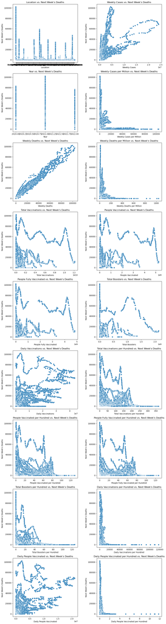

```python
cols_per_row = 2
num_cols = len([col for col in unab_variablen.columns] )
rows = (num_cols + cols_per_row - 1) // cols_per_row  #Calculation of the number of required rows

fig, axes = plt.subplots(rows, cols_per_row, figsize=(12, 5 * rows))
axes = axes.flatten()

for i, col in enumerate(unab_variablen.columns):

    sns.scatterplot(ax = axes[i], x=unab_variablen[col], y=target)
    axes[i].set_title(f"{col} vs. Next Week's Deaths")
    axes[i].set_xlabel(f"{col}")
    axes[i].set_ylabel("Next Week's Deaths")

#Hiding unnecessary axes when the number of columns is odd.
for j in range(num_cols, len(axes)):
    axes[j].set_visible(False)

plt.tight_layout()
plt.show()
```

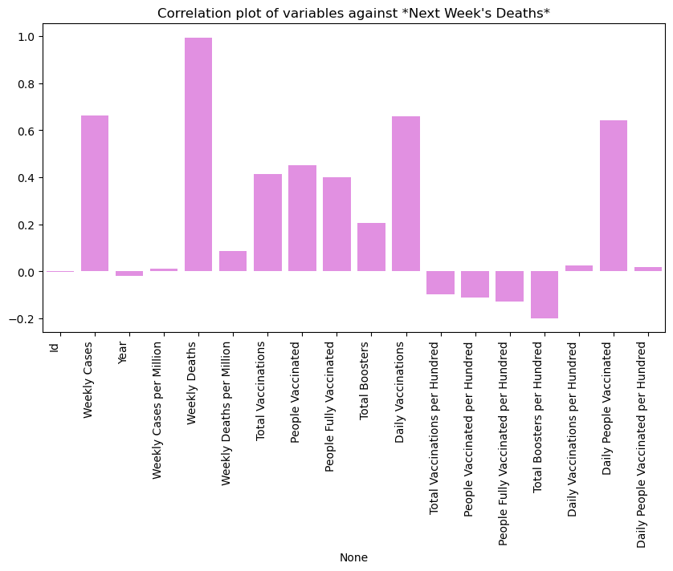

```python
correlation_matrix = data.drop('Location',axis=1).corr()
correlations_with_target = correlation_matrix["Next Week's Deaths"].drop("Next Week's Deaths")
plt.figure(figsize=(10,5))
sns.barplot(x= correlations_with_target.index, y=correlations_with_target.values, color = 'violet')
plt.title("Correlation plot of variables against *Next Week's Deaths*")
plt.xticks(rotation=90, ha='right')
plt.show()
```

#### Relationships between independent variables

```python
#Copy of original dataset
df = data.copy()
```

```python
# Deletion of NaN values, as sns.pairplot() does not accept NaN values and is also very time-consuming, especially when there are many rows..
df.dropna(axis=0, inplace=True)
#df.drop("Id", axis=1, inplace=True)
df.head()
```

|  | Id | Location | Weekly Cases | Year | Weekly Cases per Million | Weekly Deaths | Weekly Deaths per Million | Total Vaccinations | People Vaccinated | People Fully Vaccinated | Total Boosters | Daily Vaccinations | Total Vaccinations per Hundred | People Vaccinated per Hundred | People Fully Vaccinated per Hundred | Total Boosters per Hundred | Daily Vaccinations per Hundred | Daily People Vaccinated | Daily People Vaccinated per Hundred | Next Week's Deaths |
| --- | --- | --- | --- | --- | --- | --- | --- | --- | --- | --- | --- | --- | --- | --- | --- | --- | --- | --- | --- | --- |
| 241 | 275164452 | World | 4174523.0 | 2020 | 527.800 | 77527.0 | 9.802 | 11875406.0 | 7231498.0 | 44680.0 | 1.0 | 897447.0 | 0.15 | 0.09 | 0.00 | 0.0 | 113.0 | 690726.0 | 0.009 | 81042.0 |
| 242 | 857254713 | World | 4424216.0 | 2021 | 559.369 | 79456.0 | 10.046 | 13722790.0 | 9050886.0 | 58460.0 | 9.0 | 1079269.0 | 0.17 | 0.11 | 0.00 | 0.0 | 136.0 | 735617.0 | 0.009 | 92754.0 |
| 243 | 515683834 | World | 4553174.0 | 2021 | 575.674 | 80332.0 | 10.157 | 17002186.0 | 11343354.0 | 191881.0 | 15.0 | 1303377.0 | 0.21 | 0.14 | 0.00 | 0.0 | 165.0 | 851085.0 | 0.011 | 94477.0 |
| 244 | 725478352 | World | 4619286.0 | 2021 | 584.033 | 79640.0 | 10.069 | 18569106.0 | 12578084.0 | 366880.0 | 23.0 | 1397939.0 | 0.23 | 0.16 | 0.00 | 0.0 | 177.0 | 845521.0 | 0.011 | 96212.0 |
| 245 | 844503137 | World | 4649535.0 | 2021 | 587.857 | 81042.0 | 10.246 | 20361402.0 | 14002427.0 | 650359.0 | 27.0 | 1581369.0 | 0.26 | 0.18 | 0.01 | 0.0 | 200.0 | 928498.0 | 0.012 | 96742.0 |

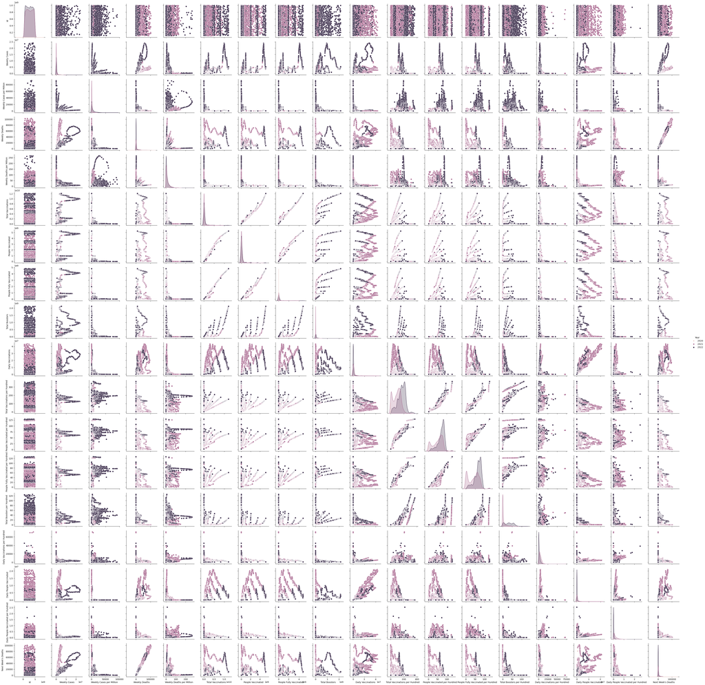

```python
#correlation between variables
sns.pairplot(data=df, hue='Year')
```

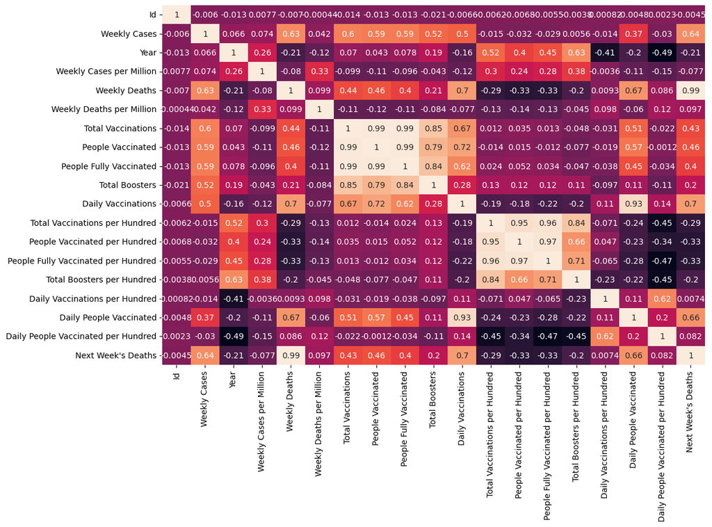

```python
plt.figure(figsize=(12,8))
sns.heatmap(df.drop('Location',axis=1).corr(), annot=True, cbar=False)
```

**From this analysis, it can be observed that some variables are positively correlated. For example:**

- **Weekly Deaths** and **Next Week's Deaths** have a correlation coefficient of **0.99**, meaning that higher **Weekly Deaths** correspond to higher **Next Week's Deaths**.
- **Daily People Vaccinated** and **Daily Vaccinations** have a correlation coefficient of **0.93**.
- **People Fully Vaccinated per Hundred** and **Total Vaccinations per Hundred** have a correlation coefficient of **0.96**.
- **People Fully Vaccinated per Hundred** and **People Vaccinated per Hundred** have a correlation coefficient of **0.97**.

#### Temporal and Geographical Analysis

```python
data
```

|  | Id | Location | Weekly Cases | Year | Weekly Cases per Million | Weekly Deaths | Weekly Deaths per Million | Total Vaccinations | People Vaccinated | People Fully Vaccinated | Total Boosters | Daily Vaccinations | Total Vaccinations per Hundred | People Vaccinated per Hundred | People Fully Vaccinated per Hundred | Total Boosters per Hundred | Daily Vaccinations per Hundred | Daily People Vaccinated | Daily People Vaccinated per Hundred | Next Week's Deaths |
| --- | --- | --- | --- | --- | --- | --- | --- | --- | --- | --- | --- | --- | --- | --- | --- | --- | --- | --- | --- | --- |
| 0 | 911530868 | World | 2372.0 | 2020 | 0.300 | 65.0 | 0.008 | NaN | NaN | NaN | NaN | NaN | NaN | NaN | NaN | NaN | NaN | NaN | NaN | 344.0 |
| 1 | 807936902 | World | 5023.0 | 2020 | 0.635 | 114.0 | 0.014 | NaN | NaN | NaN | NaN | NaN | NaN | NaN | NaN | NaN | NaN | NaN | NaN | 361.0 |
| 2 | 773590408 | World | 5612.0 | 2020 | 0.710 | 116.0 | 0.015 | NaN | NaN | NaN | NaN | NaN | NaN | NaN | NaN | NaN | NaN | NaN | NaN | 431.0 |
| 3 | 130466459 | World | 7580.0 | 2020 | 0.958 | 153.0 | 0.019 | NaN | NaN | NaN | NaN | NaN | NaN | NaN | NaN | NaN | NaN | NaN | NaN | 463.0 |
| 4 | 544040446 | World | 8983.0 | 2020 | 1.136 | 187.0 | 0.024 | NaN | NaN | NaN | NaN | NaN | NaN | NaN | NaN | NaN | NaN | NaN | NaN | 506.0 |
| ... | ... | ... | ... | ... | ... | ... | ... | ... | ... | ... | ... | ... | ... | ... | ... | ... | ... | ... | ... | ... |
| 129151 | 541829605 | Zimbabwe | 464.0 | 2022 | 29.012 | 13.0 | 0.813 | 11949993.0 | 6297324.0 | 4601845.0 | 1050824.0 | 5665.0 | 74.72 | 39.37 | 28.77 | 6.57 | 354.0 | 1427.0 | 0.009 | 9.0 |
| 129152 | 969939474 | Zimbabwe | 471.0 | 2022 | 29.449 | 12.0 | 0.750 | 11958771.0 | 6299348.0 | 4605821.0 | 1053602.0 | 5295.0 | 74.77 | 39.39 | 28.80 | 6.59 | 331.0 | 1362.0 | 0.009 | 7.0 |
| 129153 | 667902340 | Zimbabwe | 450.0 | 2022 | 28.136 | 13.0 | 0.813 | NaN | NaN | NaN | NaN | 5316.0 | NaN | NaN | NaN | NaN | 332.0 | 1483.0 | 0.009 | 5.0 |
| 129154 | 961193720 | Zimbabwe | 277.0 | 2022 | 17.320 | 6.0 | 0.375 | 11974313.0 | 6305470.0 | 4611113.0 | 1057730.0 | 5358.0 | 74.87 | 39.43 | 28.83 | 6.61 | 335.0 | 1633.0 | 0.010 | 7.0 |
| 129155 | 832612563 | Zimbabwe | 277.0 | 2022 | 17.320 | 6.0 | 0.375 | 11984914.0 | 6310089.0 | 4614738.0 | 1060087.0 | 6190.0 | 74.94 | 39.45 | 28.85 | 6.63 | 387.0 | 2102.0 | 0.013 | 8.0 |

129156 rows × 20 columns

```python
#Number of weekly cases and deaths
annual_trends = data.groupby('Year')[["Weekly Cases", "Weekly Deaths"]].sum()
annual_trends
```

| Year | Weekly Cases | Weekly Deaths |
| --- | --- | --- |
| 2020 | 1.769078e+09 | 40011144.0 |
| 2021 | 4.385636e+09 | 77041928.0 |
| 2022 | 6.120829e+09 | 20157884.0 |

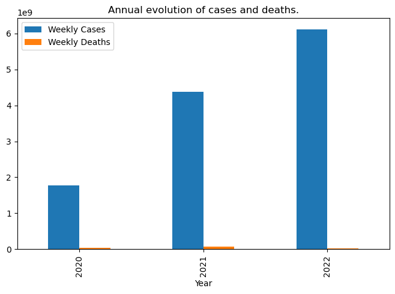

```python
annual_trends.plot(kind='bar', title='Annual evolution of cases and deaths.', figsize=(8,5))
```

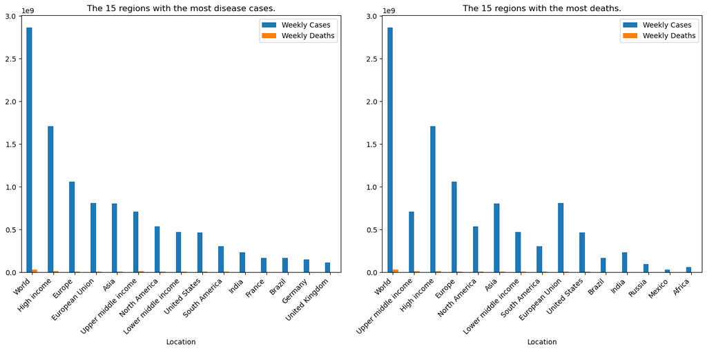

```python
# Regions with higher death rates and disease rates
regional_totals = data.groupby('Location')[['Weekly Cases', 'Weekly Deaths']].sum()

plt.figure(figsize=(14, 7))

#first
plt.subplot(1, 2, 1)
regional_totals.sort_values(by='Weekly Cases', ascending=False).head(15).plot(kind='bar', title='The 15 regions with the most disease cases.', ax=plt.gca())
plt.xticks(rotation=45, ha='right')

# second
plt.subplot(1, 2, 2)
regional_totals.sort_values(by='Weekly Deaths', ascending=False).head(15).plot(kind='bar', title='The 15 regions with the most deaths.', ax=plt.gca())
plt.xticks(rotation=45, ha='right')

plt.tight_layout()
plt.show()
```

```python
import geopandas as gpd
countries_path = "ne_110m_admin_0_countries/ne_110m_admin_0_countries.shp"
world = gpd.read_file(countries_path)
#print(world['GEOUNIT'][4])
world.loc[4, 'GEOUNIT'] = 'United States' #To have the same name of United States as in my dataset.

continents_path = "shapefiles/world-continents.shp"
continents = gpd.read_file(continents_path)
continents.rename(columns={'geometry': 'continent_geometry'}, inplace=True)

#world.head(5)
continents

# Geopandas and other files (such as: ne_110m_admin_0_countries/ne_110m_admin_0_countries.shp and shapefiles/world-continents.shp) are used here
# in order to represent on the map the different regions most affected by COVID. These files can be downloaded from the link
# here: https://www.naturalearthdata.com/downloads/110m-cultural-vectors/ in the 'Download countries' section.
```

|  | CONTINENT | SQMI | SQKM | continent_geometry |
| --- | --- | --- | --- | --- |
| 0 | Africa | 1.158346e+07 | 3.000115e+07 | MULTIPOLYGON (((35.48832 -21.685, 35.45221 -21... |
| 1 | Antarctica | 4.754809e+06 | 1.231495e+07 | MULTIPOLYGON (((-60.22 -80.28585, -60.23361 -8... |
| 2 | Asia | 1.731728e+07 | 4.485173e+07 | MULTIPOLYGON (((150.8936 -10.64874, 150.88053 ... |
| 3 | Australia | 2.973612e+06 | 7.701651e+06 | MULTIPOLYGON (((158.88218 -54.71139, 158.87967... |
| 4 | Europe | 3.821854e+06 | 9.898597e+06 | MULTIPOLYGON (((23.84853 35.52298, 23.97138 35... |
| 5 | North America | 9.339528e+06 | 2.418936e+07 | MULTIPOLYGON (((-81.67847 7.38861, -81.64945 7... |
| 6 | Oceania | 1.656787e+05 | 4.291076e+05 | MULTIPOLYGON (((169.18552 -52.57695, 169.16165... |
| 7 | South America | 6.856255e+06 | 1.775769e+07 | MULTIPOLYGON (((-67.2089 -55.89104, -67.24695 ... |

```python
#Total number of disease cases per region.
regional_cases = data.groupby('Location')['Weekly Cases'].sum().reset_index()

world_cases = world.merge(regional_cases, left_on='GEOUNIT', right_on='Location', how='outer')
world_cases['Location'] = world_cases['GEOUNIT'].combine_first(world_cases['Location'])

world_cases = world_cases.merge(continents, left_on='Location', right_on='CONTINENT', how='outer')
world_cases['geometry'] = world_cases['geometry'].combine_first(world_cases['continent_geometry'])
world_cases['Location'] = world_cases['Location'].combine_first(world_cases['CONTINENT_y'])

world_cases.head(3)
#world_cases[world_cases["Location"].duplicated()]
#world_cases = world_cases.drop_duplicates(subset=['GEOUNIT'])
```

|  | featurecla | scalerank | LABELRANK | SOVEREIGNT | SOV_A3 | ADM0_DIF | LEVEL | TYPE | TLC | ADMIN | ADM0_A3 | GEOU_DIF | GEOUNIT | GU_A3 | SU_DIF | SUBUNIT | SU_A3 | BRK_DIFF | NAME | NAME_LONG | BRK_A3 | BRK_NAME | BRK_GROUP | ABBREV | POSTAL | FORMAL_EN | FORMAL_FR | NAME_CIAWF | NOTE_ADM0 | … |
| --- | --- | --- | --- | --- | --- | --- | --- | --- | --- | --- | --- | --- | --- | --- | --- | --- | --- | --- | --- | --- | --- | --- | --- | --- | --- | --- | --- | --- | --- | --- |
| 0 | Admin-0 country | 1.0 | 6.0 | Fiji | FJI | 0.0 | 2.0 | Sovereign country | 1 | Fiji | FJI | 0.0 | Fiji | FJI | 0.0 | Fiji | FJI | 0.0 | Fiji | Fiji | FJI | Fiji | None | Fiji | FJ | Republic of Fiji | None | Fiji | None | … |
| 1 | Admin-0 country | 1.0 | 3.0 | United Republic of Tanzania | TZA | 0.0 | 2.0 | Sovereign country | 1 | United Republic of Tanzania | TZA | 0.0 | Tanzania | TZA | 0.0 | Tanzania | TZA | 0.0 | Tanzania | Tanzania | TZA | Tanzania | None | Tanz. | TZ | United Republic of Tanzania | None | Tanzania | None | … |
| 2 | Admin-0 country | 1.0 | 7.0 | Western Sahara | SAH | 0.0 | 2.0 | Indeterminate | 1 | Western Sahara | SAH | 0.0 | Western Sahara | SAH | 0.0 | Western Sahara | SAH | 1.0 | W. Sahara | Western Sahara | B28 | W. Sahara | None | W. Sah. | WS | Sahrawi Arab Democratic Republic | None | Western Sahara | None | … |

3 rows × 175 columns

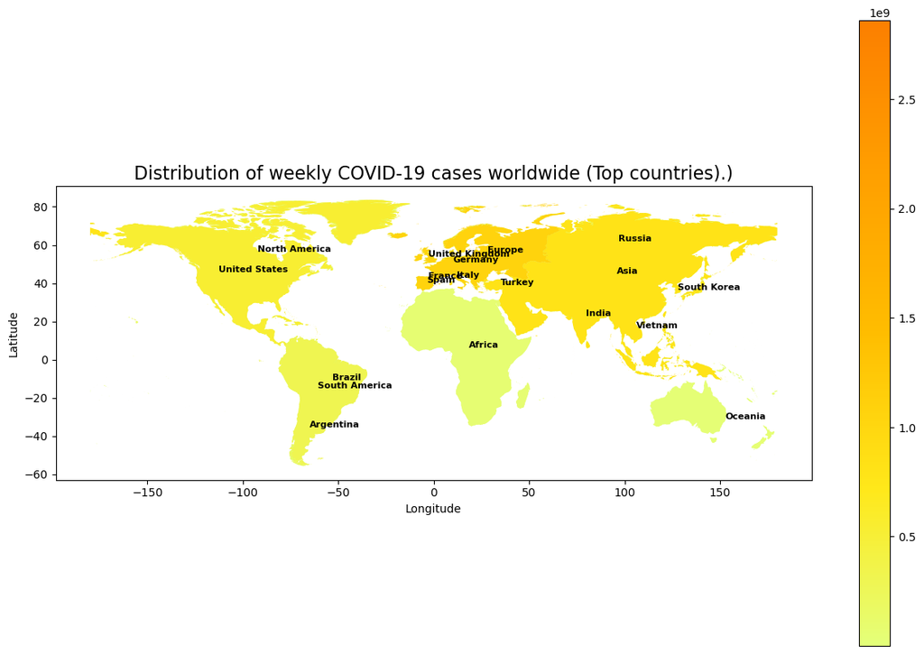

```python
ax = world_cases.plot(column='Weekly Cases', cmap='Wistia', legend=True, figsize=(15, 10))

threshold = pow(10, 7.69)

for _, row in world_cases.iterrows():
    if row['Weekly Cases'] > threshold:
        if row['geometry'] is not None:
            ax.annotate(
                text=row['Location'],
                xy=(row['geometry'].centroid.x, row['geometry'].centroid.y),
                fontsize=8,
                color='black',
                fontweight='bold'
            )


ax.set_title('Distribution of weekly COVID-19 cases worldwide (Top countries).)', fontsize=16)
ax.set_xlabel('Longitude')
ax.set_ylabel('Latitude')

plt.show()
```

```python
#Total number of deaths per region.
regional_deaths = data.groupby('Location')['Weekly Deaths'].sum().reset_index()

world_deaths = world_cases.merge(regional_deaths, left_on='Location', right_on='Location', how='outer')
world_deaths.head(3)
```

|  | featurecla | scalerank | LABELRANK | SOVEREIGNT | SOV_A3 | ADM0_DIF | LEVEL | TYPE | TLC | ADMIN | ADM0_A3 | GEOU_DIF | GEOUNIT | GU_A3 | SU_DIF | SUBUNIT | SU_A3 | BRK_DIFF | NAME | NAME_LONG | BRK_A3 | BRK_NAME | BRK_GROUP | ABBREV | POSTAL | FORMAL_EN | FORMAL_FR | NAME_CIAWF | NOTE_ADM0 | … |
| --- | --- | --- | --- | --- | --- | --- | --- | --- | --- | --- | --- | --- | --- | --- | --- | --- | --- | --- | --- | --- | --- | --- | --- | --- | --- | --- | --- | --- | --- | --- |
| 0 | Admin-0 country | 1.0 | 6.0 | Fiji | FJI | 0.0 | 2.0 | Sovereign country | 1 | Fiji | FJI | 0.0 | Fiji | FJI | 0.0 | Fiji | FJI | 0.0 | Fiji | Fiji | FJI | Fiji | None | Fiji | FJ | Republic of Fiji | None | Fiji | None | … |
| 1 | Admin-0 country | 1.0 | 3.0 | United Republic of Tanzania | TZA | 0.0 | 2.0 | Sovereign country | 1 | United Republic of Tanzania | TZA | 0.0 | Tanzania | TZA | 0.0 | Tanzania | TZA | 0.0 | Tanzania | Tanzania | TZA | Tanzania | None | Tanz. | TZ | United Republic of Tanzania | None | Tanzania | None | … |
| 2 | Admin-0 country | 1.0 | 7.0 | Western Sahara | SAH | 0.0 | 2.0 | Indeterminate | 1 | Western Sahara | SAH | 0.0 | Western Sahara | SAH | 0.0 | Western Sahara | SAH | 1.0 | W. Sahara | Western Sahara | B28 | W. Sahara | None | W. Sah. | WS | Sahrawi Arab Democratic Republic | None | Western Sahara | None | … |

3 rows × 176 columns

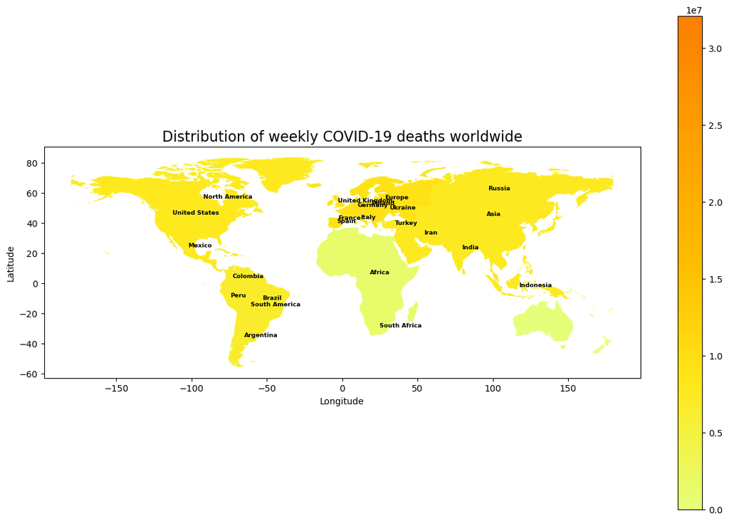

```python
ax = world_deaths.plot(column='Weekly Deaths', cmap='Wistia', legend=True, figsize=(15, 10))

threshold = pow(10, 5.60)

for _, row in world_deaths.iterrows():
    if row['Weekly Deaths'] > threshold:
        if row['geometry'] is not None:
            ax.annotate(
                text=row['Location'],
                xy=(row['geometry'].centroid.x, row['geometry'].centroid.y),
                fontsize=6.8,
                color='black',
                fontweight='bold'
            )

ax.set_title('Distribution of weekly COVID-19 deaths worldwide', fontsize=16)
ax.set_xlabel('Longitude')
ax.set_ylabel('Latitude')

plt.show()
```

#### Vaccination and its effects

```python
# The top 16 regions (or countries) with the highest vaccination rates
data_grouped_top = data.groupby(["Location"]).sum().sort_values(by = "Total Vaccinations", ascending=False).head(16)
data_grouped_top
```

| Location | Id | Weekly Cases | Year | Weekly Cases per Million | Weekly Deaths | Weekly Deaths per Million | Total Vaccinations | People Vaccinated | People Fully Vaccinated | Total Boosters | Daily Vaccinations | Total Vaccinations per Hundred | People Vaccinated per Hundred | People Fully Vaccinated per Hundred | Total Boosters per Hundred | Daily Vaccinations per Hundred | Daily People Vaccinated | Daily People Vaccinated per Hundred | Next Week's Deaths |
| --- | --- | --- | --- | --- | --- | --- | --- | --- | --- | --- | --- | --- | --- | --- | --- | --- | --- | --- | --- |
| World | 343175836065 | 2.861184e+09 | 1311529 | 361749.577 | 32099475.0 | 4058.447 | 2.496880e+12 | 1.218746e+12 | 9.768278e+11 | 2.361440e+11 | 8.928484e+09 | 31568.98 | 15409.02 | 12350.41 | 2985.62 | 1128858.0 | 3.373729e+09 | 42.648 | 32062228.0 |
| Asia | 367764316423 | 8.042532e+08 | 1345872 | 171364.344 | 7623339.0 | 1624.324 | 1.687875e+12 | 8.131908e+11 | 6.406760e+11 | 1.433659e+11 | 6.305201e+09 | 35963.95 | 17326.78 | 13650.98 | 3054.77 | 1343473.0 | 2.273782e+09 | 48.449 | 7631107.0 |
| Upper middle income | 374107922156 | 7.087520e+08 | 1370119 | 283338.992 | 13535982.0 | 5411.303 | 1.159670e+12 | 5.135934e+11 | 4.360799e+11 | 1.257807e+11 | 3.953455e+09 | 46360.36 | 20532.02 | 17433.19 | 5028.34 | 1580471.0 | 1.132104e+09 | 45.255 | 13563349.0 |
| China | 374341050981 | 3.989379e+06 | 1362031 | 2797.793 | 20054.0 | 14.068 | 7.607777e+11 | 2.963705e+10 | 3.743798e+10 | 1.161732e+10 | 2.540583e+09 | 53354.45 | 2078.48 | 2625.60 | 814.74 | 1781743.0 | 4.908809e+08 | 34.387 | 18632.0 |
| Lower middle income | 367483703569 | 4.694772e+08 | 1341833 | 139592.556 | 6832004.0 | 2031.397 | 7.548071e+11 | 4.314895e+11 | 3.023138e+11 | 2.416828e+10 | 3.256393e+09 | 22443.17 | 12829.73 | 8988.91 | 718.60 | 968251.0 | 1.607126e+09 | 47.796 | 6843420.0 |
| High income | 363980741314 | 1.709065e+09 | 1351928 | 1376752.513 | 13073223.0 | 10531.262 | 5.792576e+11 | 2.708835e+11 | 2.325204e+11 | 8.212733e+10 | 1.862288e+09 | 46662.60 | 21821.33 | 18730.84 | 6615.81 | 1500177.0 | 7.227329e+08 | 58.212 | 13044838.0 |
| India | 335873742187 | 2.337880e+08 | 1242831 | 166094.079 | 2685113.0 | 1907.633 | 3.479345e+11 | 2.088908e+11 | 1.362487e+11 | 2.793464e+09 | 1.401385e+09 | 24718.99 | 14840.59 | 9679.71 | 198.44 | 995613.0 | 7.312434e+08 | 51.945 | 2750931.0 |
| Europe | 346698622651 | 1.063511e+09 | 1295347 | 1420561.169 | 9271854.0 | 12384.673 | 2.984635e+11 | 1.390928e+11 | 1.221195e+11 | 4.154054e+10 | 9.091805e+08 | 39866.58 | 18579.04 | 16311.82 | 5548.60 | 1214416.0 | 3.529631e+08 | 47.139 | 9305360.0 |
| North America | 377356288305 | 5.375706e+08 | 1372117 | 901487.252 | 7663774.0 | 12851.878 | 2.449427e+11 | 1.215372e+11 | 1.008609e+11 | 2.424261e+10 | 7.630040e+08 | 41076.12 | 20381.34 | 16913.89 | 4065.25 | 1279537.0 | 3.215156e+08 | 53.905 | 7668808.0 |
| European Union | 374811896567 | 8.099883e+08 | 1358001 | 1809651.343 | 5861020.0 | 13094.524 | 2.201179e+11 | 1.005995e+11 | 8.945689e+10 | 3.451759e+10 | 6.553287e+08 | 49178.11 | 22475.62 | 19986.20 | 7711.81 | 1464123.0 | 2.465415e+08 | 55.078 | 5881284.0 |
| South America | 352741386470 | 3.075180e+08 | 1271115 | 708637.456 | 6587571.0 | 15180.268 | 1.724596e+11 | 8.740477e+10 | 6.713583e+10 | 2.070666e+10 | 6.501973e+08 | 39741.16 | 20141.32 | 15470.61 | 4771.61 | 1498307.0 | 2.721470e+08 | 62.717 | 6598912.0 |
| United States | 359400382866 | 4.678046e+08 | 1331739 | 1388153.889 | 5353637.0 | 15886.282 | 1.624920e+11 | 8.066272e+10 | 6.772700e+10 | 1.721284e+10 | 4.618832e+08 | 48942.06 | 24295.37 | 20399.23 | 5184.13 | 1391187.0 | 2.007561e+08 | 60.470 | 5395803.0 |
| Africa | 355472509106 | 6.303815e+07 | 1325685 | 45273.202 | 1329147.0 | 954.589 | 8.792232e+10 | 5.492479e+10 | 3.838919e+10 | 2.443066e+09 | 4.322672e+08 | 6314.50 | 3944.53 | 2757.04 | 175.47 | 310449.0 | 2.639947e+08 | 18.956 | 1327422.0 |
| Brazil | 346312487594 | 1.662298e+08 | 1252936 | 775592.243 | 3504680.0 | 16352.089 | 8.222781e+10 | 4.225591e+10 | 3.141502e+10 | 9.414485e+09 | 3.345943e+08 | 38365.75 | 19715.74 | 14657.64 | 4392.59 | 1561146.0 | 1.388454e+08 | 64.787 | 3498361.0 |
| Japan | 365314941643 | 4.872596e+07 | 1341839 | 391019.721 | 164936.0 | 1323.557 | 5.721746e+10 | 2.636771e+10 | 2.427828e+10 | 6.571470e+09 | 2.129528e+08 | 45916.23 | 21159.84 | 19483.06 | 5273.59 | 1708922.0 | 7.811961e+07 | 62.689 | 166149.0 |
| Indonesia | 362213171537 | 3.231596e+07 | 1305473 | 118047.785 | 846050.0 | 3090.564 | 5.080258e+10 | 3.632436e+10 | 2.568472e+10 | 1.795383e+09 | 3.261263e+08 | 18557.70 | 13269.16 | 9382.35 | 655.74 | 1191302.0 | 1.570545e+08 | 57.369 | 844727.0 |

```python
#Names of the top 16 countries with higher vaccination rates.
data_grouped_top_index = data_grouped_top.index
data_grouped_top_index
```

```
Index(['World', 'Asia', 'Upper middle income', 'China', 'Lower middle income',
       'High income', 'India', 'Europe', 'North America', 'European Union',
       'South America', 'United States', 'Africa', 'Brazil', 'Japan',
       'Indonesia'],
      dtype='object', name='Location')
```

```python
#Creating a DataFrame with country names as the index
data_location_as_index = data.set_index("Location")
data_location_as_index.head(4)
```

| Location | Id | Weekly Cases | Year | Weekly Cases per Million | Weekly Deaths | Weekly Deaths per Million | Total Vaccinations | People Vaccinated | People Fully Vaccinated | Total Boosters | Daily Vaccinations | Total Vaccinations per Hundred | People Vaccinated per Hundred | People Fully Vaccinated per Hundred | Total Boosters per Hundred | Daily Vaccinations per Hundred | Daily People Vaccinated | Daily People Vaccinated per Hundred | Next Week's Deaths |
| --- | --- | --- | --- | --- | --- | --- | --- | --- | --- | --- | --- | --- | --- | --- | --- | --- | --- | --- | --- |
| World | 911530868 | 2372.0 | 2020 | 0.300 | 65.0 | 0.008 | NaN | NaN | NaN | NaN | NaN | NaN | NaN | NaN | NaN | NaN | NaN | NaN | 344.0 |
| World | 807936902 | 5023.0 | 2020 | 0.635 | 114.0 | 0.014 | NaN | NaN | NaN | NaN | NaN | NaN | NaN | NaN | NaN | NaN | NaN | NaN | 361.0 |
| World | 773590408 | 5612.0 | 2020 | 0.710 | 116.0 | 0.015 | NaN | NaN | NaN | NaN | NaN | NaN | NaN | NaN | NaN | NaN | NaN | NaN | 431.0 |
| World | 130466459 | 7580.0 | 2020 | 0.958 | 153.0 | 0.019 | NaN | NaN | NaN | NaN | NaN | NaN | NaN | NaN | NaN | NaN | NaN | NaN | 463.0 |

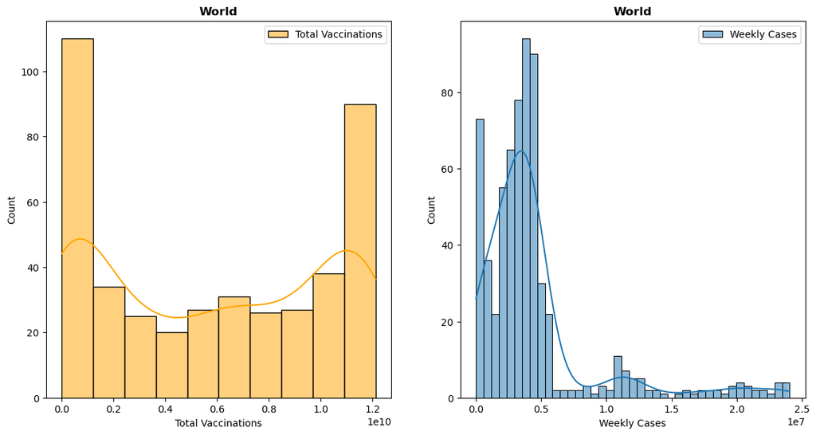

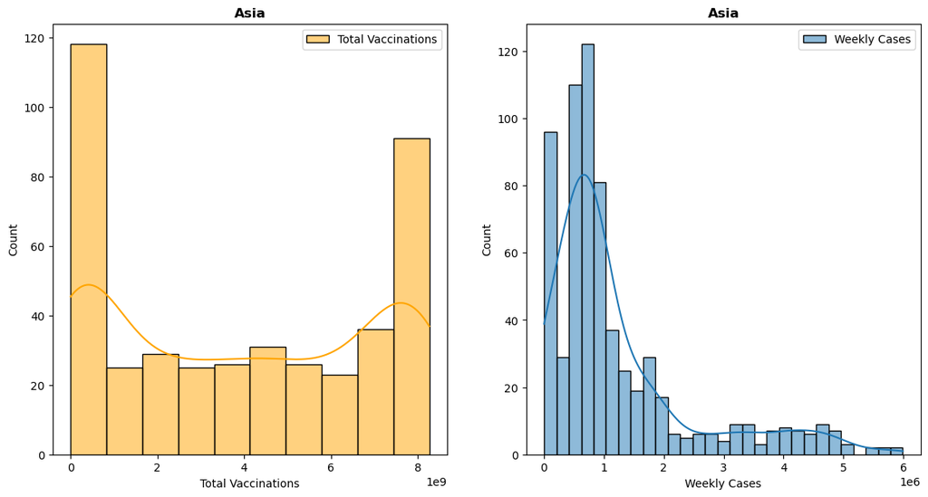

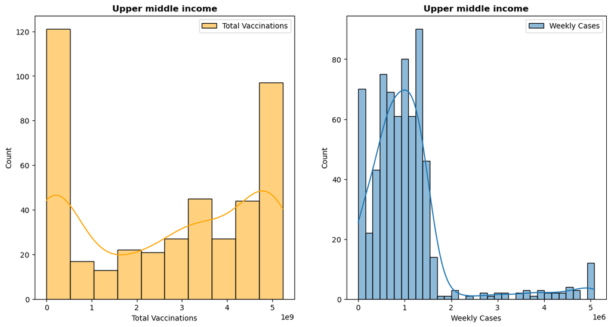

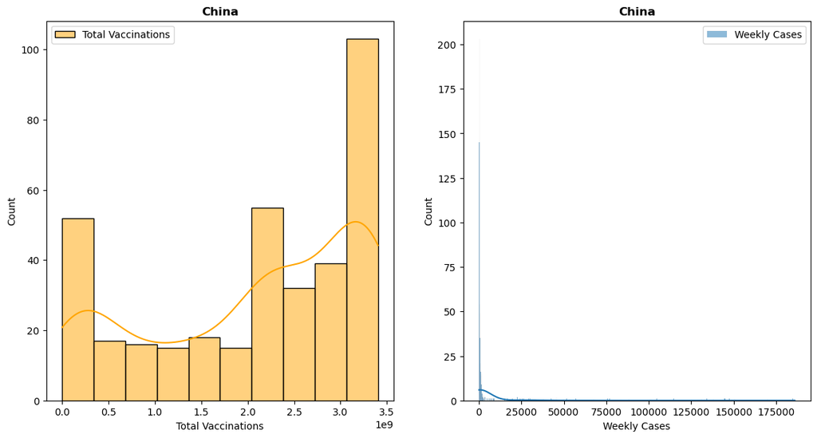

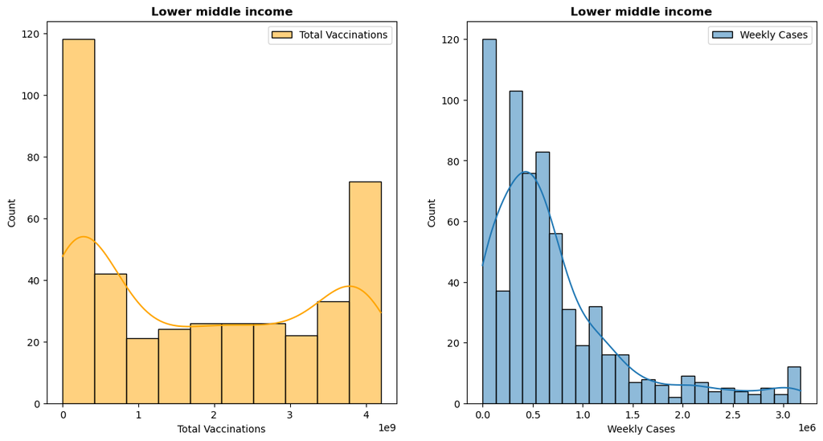

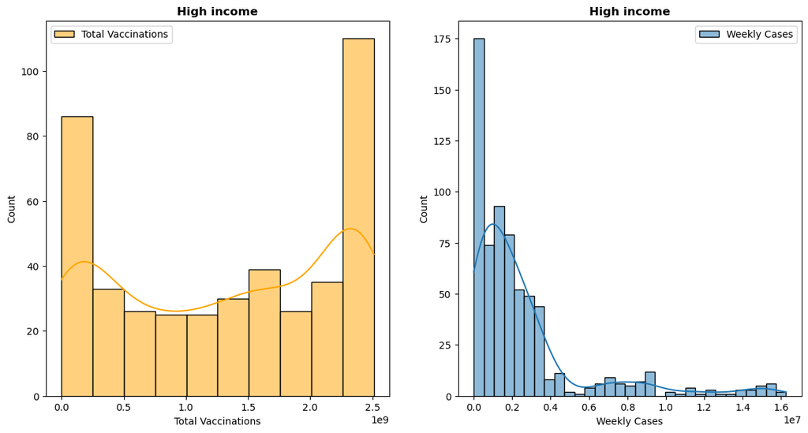

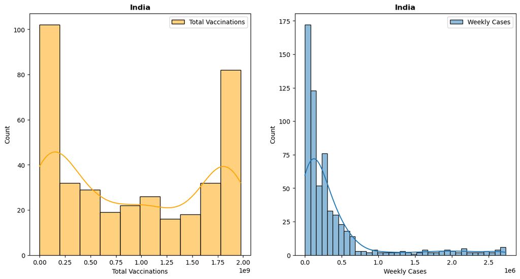

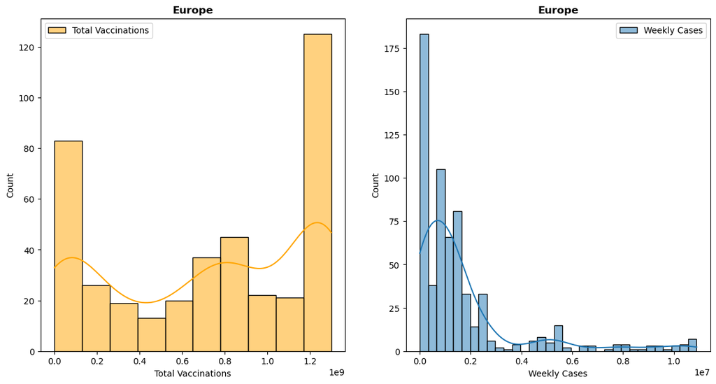

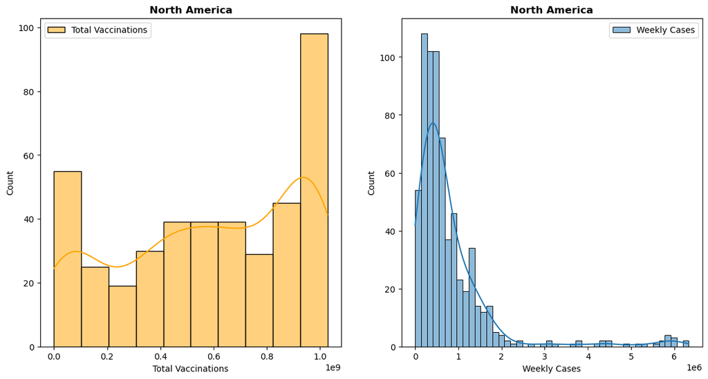

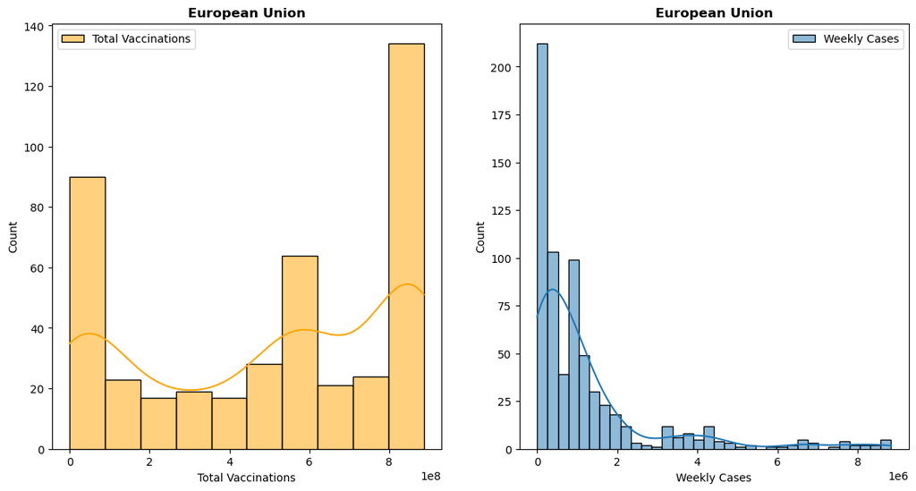

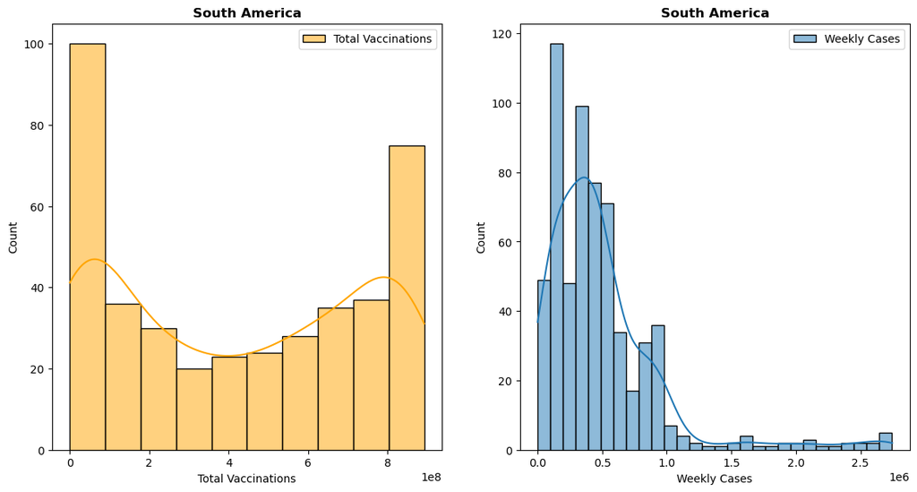

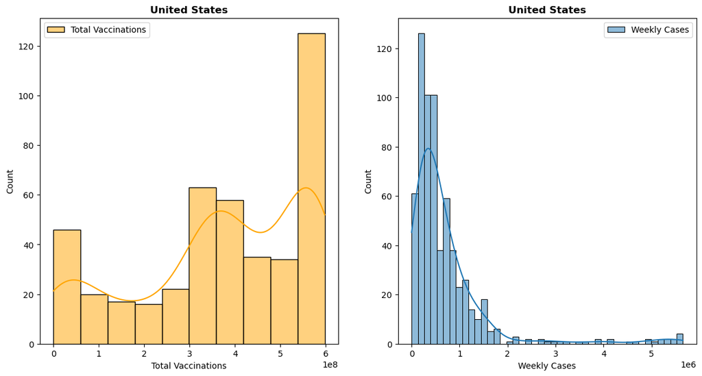

[4 more figures not shown]

```python
# Plotting the histograms of the columns 'Total Vaccinations' and 'Weekly Cases' for the top 16 countries (or regions).
for location in data_grouped_top_index:
    plt.figure(figsize=(14,7))

    plt.subplot(1, 2, 1)
    sns.histplot(data_location_as_index["Total Vaccinations"][location], label='Total Vaccinations', kde=True, color='orange')
    plt.title(f'{location}', fontweight='bold')
    plt.legend()

    plt.subplot(1, 2, 2)
    sns.histplot(data_location_as_index["Weekly Cases"][location], label='Weekly Cases', kde=True)
    plt.title(f'{location}', fontweight='bold')
    plt.legend()


    plt.show()
```

```python
#Investigation of the relationship between 'Total Vaccinations' and 'Weekly Cases'
from scipy.stats import pearsonr

df_clean = data.dropna(subset=['Weekly Cases', 'Weekly Deaths', 'Total Vaccinations'])

# Analyser der Korrelation zwischen Impfungen und Krankheitsfällen
corr_cases, _ = pearsonr(df_clean['Total Vaccinations'], df_clean['Weekly Cases'])
corr_deaths, _ = pearsonr(df_clean['Total Vaccinations'], df_clean['Weekly Deaths'])


print(f"Korrelation zwischen Total Vaccinations und Weekly Cases : {corr_cases}")
print(f"Korrelation zwischen Total Vaccinations und Weekly Deaths  : {corr_deaths}")
```

```
Korrelation zwischen Total Vaccinations und Weekly Cases : 0.5945225142453268
Korrelation zwischen Total Vaccinations und Weekly Deaths  : 0.42208650052500496
```

**The analysis shows for some countries that:**

The increase in **Total Vaccinations** is not directly correlated with a **significant reduction in weekly cases**. For example, this is the case between **Europe (Total Vaccinations: 2.984635e+11, Weekly Cases: 1.063511e+09)** and **North America (Total Vaccinations: 2.449427e+11, Weekly Cases: 5.375706e+08)**. **Europe** has a higher total number of vaccinations than **North America**, but at the same time, it has **more cases of illness than North America**, which has a lower vaccination rate. This is also the case with some other regions, such as **World and Asia**, **upper-middle-income and China**, etc.

**NOTE: ONE CANNOT CONCLUDE FROM JUST A FEW COUNTRIES THAT THE OVERALL INCREASE IN VACCINATION RATE DOES NOT LEAD TO A REDUCTION IN WEEKLY CASES. THE HYPOTHESIS TEST LATER WILL PROVIDE US WITH MORE INSIGHT.**